# Smoothing Hazard Function by using Uniform kernel Epachnikov kernel and Biweight kernel

Rongjie Huang rongjie@email.sc.edu

Department of Biostatistics, University of South Carolina

Xiran Wang xiran@email.sc.du

Department of Statistics, University of South Carolina

Anja Zgodic azgodic@email.sc.edu

Department of Biostatistics, University of South Carolina

4/2020

### Introduction

In the survival analytics, two techniques for providing summary curves which tell us about the survival experience of a cohort of individuals are presented. They are the Kaplan-Meier estimator, which provides an estimate of the survival function, and the Nelson-Aalan estimator, which provides an estimate of the cumulative hazard rate. Although these two statistical methods provide an investigator with important information about the eventual death time of an individual, they provide limited information about the mechanism of the process under study, as summarized by the hazard rate. The slope of the Nelson-Aalan estimator provides a crude estimate of the hazard rate, but this estimate is often hard to interpret. To overcome these disadvantages, the kernel-smoothing technique has been used as an essential and common tool to provide investigators a better estimator of the hazard rate function.

In this work, we invented the flexible and computationally faster functions to help users compute and estimate smoothed hazard rate functions, variances, confidence intervals and optimal values by using different kernel-smoothing methods. We also created the plot functions to help user visualize the outputs.

The major achievements and functionalities of our functions include:

- Recognizes groups in the user-provided dataset and output statistics by group if the user specified.
- Flexibly switches among kernel-smoothing methods based on users’ need.
- Takes user-defined time gird and estimate smoothed hazard rate based on user’s interested time window.
- Visualizes smoothed hazard rate functions by user-specified groups.

Here, we demonstrate the coding part and some examples. For more explanations, please refer to the project slides. You can find both the slides and the datasets at my Github https://github.com/xiranwang7/Hazard-Smooth-Functions.

### Read Example Data

```r
rm(list=ls())
library(survival)
library(KMsurv)

# Use 2 datasets as examples to test out The Functions

# Read in Bone Data
bone <- read.csv("bone.csv")
bone$time <- bone$t2
bone$status <- bone$dfree

kable(bone)%>%
  kable_styling(bootstrap_options = "striped", full_width = F)%>%
  scroll_box(width = "100%",height='300px')
```

| g | t1 | t2 | death | relapse | dfree | ta | a | tc | c | tp | p | z1 | z2 | z3 | z4 | z5 | z6 | z7 | z8 | z9 | z10 | time | status |
| --- | --- | --- | --- | --- | --- | --- | --- | --- | --- | --- | --- | --- | --- | --- | --- | --- | --- | --- | --- | --- | --- | --- | --- |
| 1 | 2081 | 2081 | 0 | 0 | 0 | 67 | 1 | 121 | 1 | 13 | 1 | 26 | 33 | 1 | 0 | 1 | 1 | 98 | 0 | 1 | 0 | 2081 | 0 |
| 1 | 1602 | 1602 | 0 | 0 | 0 | 1602 | 0 | 139 | 1 | 18 | 1 | 21 | 37 | 1 | 1 | 0 | 0 | 1720 | 0 | 1 | 0 | 1602 | 0 |
| 1 | 1496 | 1496 | 0 | 0 | 0 | 1496 | 0 | 307 | 1 | 12 | 1 | 26 | 35 | 1 | 1 | 1 | 0 | 127 | 0 | 1 | 0 | 1496 | 0 |
| 1 | 1462 | 1462 | 0 | 0 | 0 | 70 | 1 | 95 | 1 | 13 | 1 | 17 | 21 | 0 | 1 | 0 | 0 | 168 | 0 | 1 | 0 | 1462 | 0 |
| 1 | 1433 | 1433 | 0 | 0 | 0 | 1433 | 0 | 236 | 1 | 12 | 1 | 32 | 36 | 1 | 1 | 1 | 1 | 93 | 0 | 1 | 0 | 1433 | 0 |
| 1 | 1377 | 1377 | 0 | 0 | 0 | 1377 | 0 | 123 | 1 | 12 | 1 | 22 | 31 | 1 | 1 | 1 | 1 | 2187 | 0 | 1 | 0 | 1377 | 0 |
| 1 | 1330 | 1330 | 0 | 0 | 0 | 1330 | 0 | 96 | 1 | 17 | 1 | 20 | 17 | 1 | 0 | 1 | 1 | 1006 | 0 | 1 | 0 | 1330 | 0 |
| 1 | 996 | 996 | 0 | 0 | 0 | 72 | 1 | 121 | 1 | 12 | 1 | 22 | 24 | 1 | 0 | 0 | 0 | 1319 | 0 | 1 | 0 | 996 | 0 |
| 1 | 226 | 226 | 0 | 0 | 0 | 226 | 0 | 226 | 0 | 10 | 1 | 18 | 21 | 0 | 1 | 0 | 0 | 208 | 0 | 1 | 0 | 226 | 0 |
| 1 | 1199 | 1199 | 0 | 0 | 0 | 1199 | 0 | 91 | 1 | 29 | 1 | 24 | 40 | 1 | 1 | 0 | 1 | 174 | 0 | 3 | 1 | 1199 | 0 |
| 1 | 1111 | 1111 | 0 | 0 | 0 | 1111 | 0 | 1111 | 0 | 22 | 1 | 19 | 28 | 1 | 1 | 0 | 1 | 236 | 0 | 3 | 1 | 1111 | 0 |
| 1 | 530 | 530 | 0 | 0 | 0 | 38 | 1 | 84 | 1 | 34 | 1 | 17 | 28 | 1 | 1 | 0 | 0 | 151 | 0 | 3 | 1 | 530 | 0 |
| 1 | 1182 | 1182 | 0 | 0 | 0 | 1182 | 0 | 112 | 1 | 22 | 1 | 24 | 23 | 0 | 0 | 0 | 1 | 203 | 0 | 2 | 1 | 1182 | 0 |
| 1 | 1167 | 1167 | 0 | 0 | 0 | 39 | 1 | 487 | 1 | 1167 | 0 | 27 | 22 | 0 | 1 | 1 | 1 | 191 | 0 | 2 | 1 | 1167 | 0 |
| 1 | 418 | 418 | 1 | 0 | 1 | 418 | 0 | 220 | 1 | 21 | 1 | 18 | 14 | 1 | 1 | 0 | 0 | 110 | 0 | 1 | 0 | 418 | 1 |
| 1 | 417 | 383 | 1 | 1 | 1 | 417 | 0 | 417 | 0 | 16 | 1 | 15 | 20 | 1 | 1 | 0 | 0 | 824 | 0 | 1 | 0 | 383 | 1 |
| 1 | 276 | 276 | 1 | 0 | 1 | 276 | 0 | 81 | 1 | 21 | 1 | 18 | 5 | 0 | 0 | 0 | 0 | 146 | 0 | 1 | 0 | 276 | 1 |
| 1 | 156 | 104 | 1 | 1 | 1 | 28 | 1 | 156 | 0 | 20 | 1 | 20 | 33 | 1 | 1 | 0 | 1 | 85 | 0 | 1 | 0 | 104 | 1 |
| 1 | 781 | 609 | 1 | 1 | 1 | 781 | 0 | 781 | 0 | 26 | 1 | 27 | 27 | 1 | 0 | 1 | 1 | 187 | 0 | 1 | 0 | 609 | 1 |
| 1 | 172 | 172 | 1 | 0 | 1 | 22 | 1 | 172 | 0 | 37 | 1 | 40 | 37 | 0 | 0 | 0 | 1 | 129 | 0 | 1 | 0 | 172 | 1 |
| 1 | 487 | 487 | 1 | 0 | 1 | 487 | 0 | 76 | 1 | 22 | 1 | 22 | 20 | 1 | 1 | 0 | 0 | 128 | 0 | 1 | 0 | 487 | 1 |
| 1 | 716 | 662 | 1 | 1 | 1 | 716 | 0 | 716 | 0 | 17 | 1 | 28 | 32 | 1 | 1 | 0 | 0 | 84 | 0 | 1 | 0 | 662 | 1 |
| 1 | 194 | 194 | 1 | 0 | 1 | 194 | 0 | 94 | 1 | 25 | 1 | 26 | 32 | 0 | 1 | 0 | 0 | 329 | 0 | 1 | 0 | 194 | 1 |
| 1 | 371 | 230 | 1 | 1 | 1 | 371 | 0 | 184 | 1 | 9 | 1 | 39 | 31 | 0 | 1 | 0 | 1 | 147 | 0 | 1 | 0 | 230 | 1 |
| 1 | 526 | 526 | 1 | 0 | 1 | 526 | 0 | 121 | 1 | 11 | 1 | 15 | 20 | 1 | 1 | 0 | 0 | 943 | 0 | 1 | 0 | 526 | 1 |
| 1 | 122 | 122 | 1 | 0 | 1 | 88 | 1 | 122 | 0 | 13 | 1 | 20 | 26 | 1 | 0 | 0 | 1 | 2616 | 0 | 1 | 0 | 122 | 1 |
| 1 | 1279 | 129 | 1 | 1 | 1 | 1279 | 0 | 1279 | 0 | 22 | 1 | 17 | 20 | 0 | 0 | 0 | 0 | 937 | 0 | 3 | 1 | 129 | 1 |
| 1 | 110 | 74 | 1 | 1 | 1 | 110 | 0 | 110 | 0 | 49 | 1 | 28 | 25 | 1 | 0 | 1 | 0 | 303 | 0 | 3 | 1 | 74 | 1 |
| 1 | 243 | 122 | 1 | 1 | 1 | 243 | 0 | 243 | 0 | 23 | 1 | 37 | 38 | 0 | 1 | 1 | 1 | 170 | 0 | 3 | 1 | 122 | 1 |
| 1 | 86 | 86 | 1 | 0 | 1 | 86 | 0 | 86 | 0 | 86 | 0 | 17 | 26 | 1 | 0 | 1 | 0 | 239 | 0 | 3 | 1 | 86 | 1 |

[output cut: 107 more lines]

```r
# Read in Kidney Data
kid <- read.csv("kidney.csv")
kid$time   <- kid$time/365
kid$status <- kid$death

kable(kid)%>%
  kable_styling(bootstrap_options = "striped", full_width = F)%>%
  scroll_box(width = "100%",height='300px')
```

| obs | time | death | gender | race | age | status |
| --- | --- | --- | --- | --- | --- | --- |
| 1 | 0.0027397 | 0 | 1 | 1 | 46 | 0 |
| 2 | 0.0136986 | 0 | 1 | 1 | 51 | 0 |
| 3 | 0.0191781 | 1 | 1 | 1 | 55 | 1 |
| 4 | 0.0246575 | 0 | 1 | 1 | 57 | 0 |
| 5 | 0.0356164 | 0 | 1 | 1 | 45 | 0 |
| 6 | 0.0356164 | 0 | 1 | 1 | 43 | 0 |
| 7 | 0.0465753 | 1 | 1 | 1 | 47 | 1 |
| 8 | 0.0547945 | 0 | 1 | 1 | 65 | 0 |
| 9 | 0.0712329 | 1 | 1 | 1 | 55 | 1 |
| 10 | 0.0712329 | 1 | 1 | 1 | 44 | 1 |
| 11 | 0.0767123 | 1 | 1 | 1 | 49 | 1 |
| 12 | 0.0876712 | 0 | 1 | 1 | 52 | 0 |
| 13 | 0.0876712 | 0 | 1 | 1 | 31 | 0 |
| 14 | 0.1178082 | 0 | 1 | 1 | 63 | 0 |
| 15 | 0.1178082 | 1 | 1 | 1 | 55 | 1 |
| 16 | 0.1205479 | 1 | 1 | 1 | 50 | 1 |
| 17 | 0.1397260 | 0 | 1 | 1 | 49 | 0 |
| 18 | 0.1397260 | 0 | 1 | 1 | 35 | 0 |
| 19 | 0.1397260 | 0 | 1 | 1 | 23 | 0 |
| 20 | 0.1534247 | 1 | 1 | 1 | 57 | 1 |
| 21 | 0.1561644 | 1 | 1 | 1 | 45 | 1 |
| 22 | 0.1616438 | 1 | 1 | 1 | 41 | 1 |
| 23 | 0.1698630 | 1 | 1 | 1 | 38 | 1 |
| 24 | 0.1808219 | 0 | 1 | 1 | 55 | 0 |
| 25 | 0.1808219 | 0 | 1 | 1 | 45 | 0 |
| 26 | 0.1835616 | 0 | 1 | 1 | 44 | 0 |
| 27 | 0.1863014 | 1 | 1 | 1 | 45 | 1 |
| 28 | 0.1890411 | 1 | 1 | 1 | 65 | 1 |
| 29 | 0.2164384 | 0 | 1 | 1 | 66 | 0 |
| 30 | 0.2164384 | 1 | 1 | 1 | 57 | 1 |

[output cut: 833 more lines]

### Kernel functions

```r
#### Uniform kernel
k.unif <- function(t,ti,td,b){
  x<-(t-ti)/b
  #Symmetric uniform kernel
  if (t>=b & t<=td-b & x>=-1 & x<=1){
    k<-1/2
    return(k)
  }
  #Asymmetric uniform kernel
  if (t<b & x>=-1 & x<=t/b){
    q<-t/b
    k<-4*(1+q^3)/(1+q)^4 + 6*(1-q)*x/(1+q)^3
    return(k)
  }
  #Asymmetric uniform kernel(negative x)
  if (t>td-b & t<td & -x>=-1 & -x<=(td-t)/b){
    q<-(td-t)/b
    x<--x
    k<-4*(1+q^3)/(1+q)^4 + 6*(1-q)*x/(1+q)^3
    return(k)
  }
  #Asymmetric uniform kernel(negative x) x>=td
  if (t>=td & -x>=-1 & -x<=(td-t)/b){
    q<-(td-t)/b
    x<--x
    k<-4*(1+q^3)/(1+q)^4 + 6*(1-q)*x/(1+q)^3
    return(k)
  }
  #x is out of bound
  else
  {
    k<-0
    return(k)
  }
}


#### Epachnikov kernel
k.ep <- function(t,ti,td,b){
  x<-(t-ti)/b
  #Symmetric Epanechnikov kernel
  if (t>=b & t<=td-b & x>=-1 & x<=1){
    k<-0.75*(1-x^2)
    return(k)
  }
  #Asymmetric Epanechnikov kernel
  if (t<b & x>=-1 & x<=t/b){
    q<-t/b
    alpha<-64*(2-4*q+6*q^2-3*q^3)/((1+q)^4*(19-18*q+3*q^2))
    beta<-240*(1-q)^2/((1+q)^4*(19-18*q+3*q^2))
    k<-0.75*(1-x^2)*(alpha+beta*x)
    return(k)
  }
  #Asymmetric Epanechnikov kernel (negative x)
  if (t>td-b & t<td & -x>=-1 & -x<=(td-t)/b){
    q<-(td-t)/b
    x<--x
    alpha<-64*(2-4*q+6*q^2-3*q^3)/((1+q)^4*(19-18*q+3*q^2))
    beta<-240*(1-q)^2/((1+q)^4*(19-18*q+3*q^2))
    k<-0.75*(1-x^2)*(alpha+beta*x)
    return(k)
  }
  #Asymmetric Epanechnikov kernel (negative x) when t >=td
  if (t>=td  & -x>=-1 & -x<=(td-t)/b){
    q<-(td-t)/b
    x<--x
    alpha<-64*(2-4*q+6*q^2-3*q^3)/((1+q)^4*(19-18*q+3*q^2))
    beta<-240*(1-q)^2/((1+q)^4*(19-18*q+3*q^2))
    k<-0.75*(1-x^2)*(alpha+beta*x)
    return(k)
  }


  else
  {
    k<-0
    return(k)
  }
}

#### Biweight kernel
k.biw <- function(t,ti,td,b){
  x<-(t-ti)/b
  #Symmetric biweight kernel
  if(t>=b & t<=td-b & x>=-1 & x<=1){
    k<-15/16*(1-x^2)^2
    return(round(k,4))
  }
  #Asymmetric biweight kernel
  if (t<b & x>=-1 & x<=1){
    q<-t/b
    alpha<-64*(8-24*q+48*q^2-45*q^3+15*q^4)*(1+q)^(-5)*(81-168*q+126*q^2-40*q^3+5*q^4)^(-1)
    beta<-1120*(1-q)^3*(1+q)^(-5)*(81-168*q+126*q^2-40*q^3+5*q^4)^(-1)
    k<-15/16*(1-x^2)^2*(alpha+beta*x)
    return(round(k,4))
  }
  #Asymmetric biweight kernel (negative x)
  if (t>td-b & t<td & -x>=-1 & -x<=(td-t)/b){
    q<-(td-t)/b
    x<--x
    alpha<-64*(8-24*q+48*q^2-45*q^3+15*q^4)*(1+q)^(-5)*(81-168*q+126*q^2-40*q^3+5*q^4)^(-1)
    beta<-1120*(1-q)^3*(1+q)^(-5)*(81-168*q+126*q^2-40*q^3+5*q^4)^(-1)
    k<-15/16*(1-x^2)^2*(alpha+beta*x)
    return(round(k,4))
  }

  #Asymmetric biweight kernel (negative x) t>=td
  if ( t>=td & -x>=-1 & -x<=(td-t)/b){
    q<-(td-t)/b
    x<--x
    alpha<-64*(8-24*q+48*q^2-45*q^3+15*q^4)*(1+q)^(-5)*(81-168*q+126*q^2-40*q^3+5*q^4)^(-1)
    beta<-1120*(1-q)^3*(1+q)^(-5)*(81-168*q+126*q^2-40*q^3+5*q^4)^(-1)
    k<-15/16*(1-x^2)^2*(alpha+beta*x)
    return(round(k,4))
  }
  #x is out of bound
  else
  {
    k<-0
    return(round(k,4))
  }
}
```

### Kernel-smoothing calculations for Epachnikov Kernel

```r
smoothing_calculation_ep <- function(data,b,user_t,group=''){

  if(group==''){
    fit <- survfit(Surv(time, status) ~ 1,data=data, ctype=1)
    t_i <- summary(fit)$time
    cumhaz <- summary(fit)$cumhaz
    delta_cumhaz <- c(cumhaz[1], diff(cumhaz))
    varcumhar <- (summary(fit)$std.chaz)^2
    delta_varcumhar <- c(varcumhar[1], diff(varcumhar))

    x <- matrix(NA,nrow=length(t_i),ncol = length(user_t))
    kernels<-matrix(NA,nrow=length(t_i),ncol = length(user_t))
    td <- max(t_i)
    for (t in 1:length (user_t)){
      for (i in 1:length(t_i)){
        x[i,t] <- (user_t[t]-t_i[i])/b
        kernels[i,t]<- k.ep(t=user_t[t],ti=t_i[i],td,b)
      }
    }

    out <- cbind(t_i, delta_cumhaz, delta_varcumhar, x, kernels)
    out <- data.frame(out)
    colnames(out) <- c("t_i", "delta_cumhaz", "delta_varcumhar", paste0(user_t, "-t_i/", b),  paste0("K(",user_t, "-t_i/", b,")"))
    return(out)
  }


  if(group!=''){
    fit <- survfit(Surv(time, status) ~ data[,group], data=data, ctype=1)
    g <- vector("list", length = length(summary(fit)$n))
    t_i <- vector("list", length = length(summary(fit)$n))
    cumhaz <- vector("list", length = length(summary(fit)$n))
    delta_cumhaz <- vector("list", length = length(summary(fit)$n))
    varcumhar <- vector("list", length = length(summary(fit)$n))
    delta_varcumhar <- vector("list", length = length(summary(fit)$n))
    out <- vector("list", length = length(summary(fit)$n))

    breaks <- c(which(diff(summary(fit)$time)<0), length(summary(fit)$time))
    t_i[[1]] <- summary(fit)$time[1:breaks[1]]
    g[[1]] <- rep(unique(data[, group])[1], length(t_i[[1]]))
    cumhaz[[1]] <- summary(fit)$cumhaz[1:breaks[1]]
    varcumhar[[1]] <- (summary(fit)$std.chaz[1:breaks[1]])^2
    delta_cumhaz[[1]] <- c(cumhaz[[1]][1], diff(cumhaz[[1]]))
    delta_varcumhar[[1]] <- c(varcumhar[[1]][1], diff(varcumhar[[1]]))

    for(l in 2:length(breaks)){
      t_i[[l]] <- summary(fit)$time[(breaks[l-1]+1):breaks[l]]
      g[[l]] <- rep(unique(data[, group])[l], length(t_i[[l]]))
      cumhaz[[l]] <- summary(fit)$cumhaz[(breaks[l-1]+1):breaks[l]]
      varcumhar[[l]] <- (summary(fit)$std.chaz[(breaks[l-1]+1):breaks[l]])^2
      delta_cumhaz[[l]] <- c(cumhaz[[l]][1], diff(cumhaz[[l]]))
      delta_varcumhar[[l]] <- c(varcumhar[[l]][1], diff(varcumhar[[l]]))
    }

    x = kernels = td <- c()
    for(l in 1:length(summary(fit)$n)){
      x[[l]] <- matrix(NA,nrow=length(t_i[[l]]),ncol = length(user_t))
      kernels[[l]] <-matrix(NA,nrow=length(t_i[[l]]),ncol = length(user_t))
      td[[l]] <- max(t_i[[l]])
    }

    for(l in 1:length(summary(fit)$n)){
      for (t in 1:length(user_t)) {
        for (i in 1:length(t_i[[l]])) {
          x[[l]][i,t] <- (user_t[t]-t_i[[l]][i])/b
          kernels[[l]][i,t]<- k.ep(t=user_t[t],ti=t_i[[l]][i],td[[l]],b) #if statement for different kernels, I can add later
        }
      }
    }

    for(l in 1:length(summary(fit)$n)){
      out[[l]]  <- cbind(g[[l]], t_i[[l]], delta_cumhaz[[l]], delta_varcumhar[[l]], x[[l]], kernels[[l]])
    }

    out <- do.call("rbind", out)
    out <- data.frame(out)
    colnames(out) <- c("group", "t_i", "delta_cumhaz", "delta_varcumhar", paste0(user_t, "-t_i/", b),  paste0("K(",user_t, "-t_i/", b,")"))

    return(out)
  }
}
```

```r
user_t <- c(150, 50, 600)
timegrid <- seq(1,662,1)
b <- 100

table1 <- smoothing_calculation_ep(data=bone, b=b, user_t=user_t, group='g')  # group='g': output group='g'by group
#table1 <- smoothing_calculation_ep(data=bone, b=b, user_t=user_t, group='')  # group='': null
#table1 <- smoothing_calculation_ep(data=bone[bone$g==1,], b=b, user_t=user_t, group='')

kable(table1)%>%
  kable_styling(bootstrap_options = "striped", full_width = F)%>%
  scroll_box(width = "100%",height = "300px")
```

| group | t_i | delta_cumhaz | delta_varcumhar | 150-t_i/100 | 50-t_i/100 | 600-t_i/100 | K(150-t_i/100) | K(50-t_i/100) | K(600-t_i/100) |
| --- | --- | --- | --- | --- | --- | --- | --- | --- | --- |
| 1 | 1 | 0.0263158 | 0.0006925 | 1.49 | 0.49 | 5.99 | 0.000000 | 1.0618964 | 0.0000000 |
| 1 | 55 | 0.0270270 | 0.0007305 | 0.95 | -0.05 | 5.45 | 0.073125 | 0.9485271 | 0.0000000 |
| 1 | 74 | 0.0277778 | 0.0007716 | 0.76 | -0.24 | 5.26 | 0.316800 | 0.7480757 | 0.0000000 |
| 1 | 86 | 0.0285714 | 0.0008163 | 0.64 | -0.36 | 5.14 | 0.442800 | 0.6045569 | 0.0000000 |
| 1 | 104 | 0.0294118 | 0.0008651 | 0.46 | -0.54 | 4.96 | 0.591300 | 0.3865997 | 0.0000000 |
| 1 | 107 | 0.0303030 | 0.0009183 | 0.43 | -0.57 | 4.93 | 0.611325 | 0.3516800 | 0.0000000 |
| 1 | 109 | 0.0312500 | 0.0009766 | 0.41 | -0.59 | 4.91 | 0.623925 | 0.3288136 | 0.0000000 |
| 1 | 110 | 0.0322581 | 0.0010406 | 0.40 | -0.60 | 4.90 | 0.630000 | 0.3175194 | 0.0000000 |
| 1 | 122 | 0.0666667 | 0.0022222 | 0.28 | -0.72 | 4.78 | 0.691200 | 0.1911467 | 0.0000000 |
| 1 | 129 | 0.0357143 | 0.0012755 | 0.21 | -0.79 | 4.71 | 0.716925 | 0.1274369 | 0.0000000 |
| 1 | 172 | 0.0370370 | 0.0013717 | -0.22 | -1.22 | 4.28 | 0.713700 | 0.0000000 | 0.0000000 |
| 1 | 192 | 0.0384615 | 0.0014793 | -0.42 | -1.42 | 4.08 | 0.617700 | 0.0000000 | 0.0000000 |
| 1 | 194 | 0.0400000 | 0.0016000 | -0.44 | -1.44 | 4.06 | 0.604800 | 0.0000000 | 0.0000000 |
| 1 | 230 | 0.0434783 | 0.0018904 | -0.80 | -1.80 | 3.70 | 0.270000 | 0.0000000 | 0.0000000 |
| 1 | 276 | 0.0454545 | 0.0020661 | -1.26 | -2.26 | 3.24 | 0.000000 | 0.0000000 | 0.0000000 |
| 1 | 332 | 0.0476190 | 0.0022676 | -1.82 | -2.82 | 2.68 | 0.000000 | 0.0000000 | 0.0000000 |
| 1 | 383 | 0.0500000 | 0.0025000 | -2.33 | -3.33 | 2.17 | 0.000000 | 0.0000000 | 0.0000000 |
| 1 | 418 | 0.0526316 | 0.0027701 | -2.68 | -3.68 | 1.82 | 0.000000 | 0.0000000 | 0.0000000 |
| 1 | 466 | 0.0555556 | 0.0030864 | -3.16 | -4.16 | 1.34 | 0.000000 | 0.0000000 | 0.0000000 |
| 1 | 487 | 0.0588235 | 0.0034602 | -3.37 | -4.37 | 1.13 | 0.000000 | 0.0000000 | 0.0000000 |
| 1 | 526 | 0.0625000 | 0.0039063 | -3.76 | -4.76 | 0.74 | 0.000000 | 0.0000000 | 0.2491607 |
| 1 | 609 | 0.0714286 | 0.0051020 | -4.59 | -5.59 | -0.09 | 0.000000 | 0.0000000 | 0.8917628 |
| 1 | 662 | 0.0769231 | 0.0059172 | -5.12 | -6.12 | -0.62 | 0.000000 | 0.0000000 | 0.6903636 |
| 2 | 10 | 0.0185185 | 0.0003429 | 1.40 | 0.40 | 5.90 | 0.000000 | 1.1113178 | 0.0000000 |
| 2 | 35 | 0.0188679 | 0.0003560 | 1.15 | 0.15 | 5.65 | 0.000000 | 1.0911628 | 0.0000000 |
| 2 | 48 | 0.0192308 | 0.0003698 | 1.02 | 0.02 | 5.52 | 0.000000 | 1.0083820 | 0.0000000 |
| 2 | 53 | 0.0196078 | 0.0003845 | 0.97 | -0.03 | 5.47 | 0.044325 | 0.9665712 | 0.0000000 |
| 2 | 79 | 0.0200000 | 0.0004000 | 0.71 | -0.29 | 5.21 | 0.371925 | 0.6891733 | 0.0000000 |
| 2 | 80 | 0.0204082 | 0.0004165 | 0.70 | -0.30 | 5.20 | 0.382500 | 0.6772093 | 0.0000000 |
| 2 | 105 | 0.0208333 | 0.0004340 | 0.45 | -0.55 | 4.95 | 0.598125 | 0.3748837 | 0.0000000 |

[output cut: 51 more lines]

### Estimated smoothed hazard function

```r
est_haz <-function(data,b,timegrid,group='',kernel='ep'){

  if(group==''){
    fit <- survfit(Surv(time, status) ~ 1,data=data, ctype=1)
    t_i <- summary(fit)$time
    cumhaz <- summary(fit)$cumhaz
    delta_cumhaz <- c(cumhaz[1], diff(cumhaz))
    td <- max(t_i)

    kernels<-matrix(NA,nrow=length(timegrid),ncol=length(t_i))

    if(kernel=="ep"){
      for (i in 1:length(timegrid)){
        for (j in 1:length(t_i)){
          kernels[i,j] <- k.ep(t=timegrid[i],ti=t_i[j],td,b)*delta_cumhaz[j]
        }
      }
    }

    if(kernel=="unif"){
      for (i in 1:length(timegrid)){
        for (j in 1:length(t_i)){
          kernels[i,j] <- k.unif(t=timegrid[i],ti=t_i[j],td,b)*delta_cumhaz[j]
        }
      }
    }

    if(kernel=="biw"){
      for (i in 1:length(timegrid)){
        for (j in 1:length(t_i)){
          kernels[i,j] <- k.biw(t=timegrid[i],ti=t_i[j],td,b)*delta_cumhaz[j]
        }
      }
    }

    haz <- rowSums(kernels, na.rm = T)/b
    haz <- data.frame(timegrid, haz)
    return(haz)
  }


  if(group!=''){
    fit <- survfit(Surv(time, status) ~ data[,group], data=data, ctype=1)
    g <- vector("list", length = length(summary(fit)$n))
    t_i <- vector("list", length = length(summary(fit)$n))
    cumhaz <- vector("list", length = length(summary(fit)$n))
    delta_cumhaz <- vector("list", length = length(summary(fit)$n))

    breaks <- c(which(diff(summary(fit)$time)<0), length(summary(fit)$time))
    t_i[[1]] <- summary(fit)$time[1:breaks[1]]
    g[[1]] <- rep(unique(data[, group])[1], length(t_i[[1]]))
    cumhaz[[1]] <- summary(fit)$cumhaz[1:breaks[1]]
    delta_cumhaz[[1]] <- c(cumhaz[[1]][1], diff(cumhaz[[1]]))

    for(l in 2:length(breaks)){
      t_i[[l]] <- summary(fit)$time[(breaks[l-1]+1):breaks[l]]
      g[[l]] <- rep(unique(data[, group])[l], length(t_i[[l]]))
      cumhaz[[l]] <- summary(fit)$cumhaz[(breaks[l-1]+1):breaks[l]]
      delta_cumhaz[[l]] <- c(cumhaz[[l]][1], diff(cumhaz[[l]]))
    }

    x = kernels = td <- c()
    for(l in 1:length(summary(fit)$n)){
      kernels[[l]] <-matrix(NA,nrow=length(timegrid), ncol = length(t_i[[l]]))
      td[[l]] <- max(t_i[[l]])
    }


    if(kernel=="ep"){
      for(l in 1:length(summary(fit)$n)){
        for (i in 1:length(timegrid)){
          for (j in 1:length(t_i[[l]])){
            kernels[[l]][i,j] <- k.ep(t=timegrid[i],ti=t_i[[l]][j],td[[l]],b)*delta_cumhaz[[l]][j]
          }
        }
      }
    }

    if(kernel=="unif"){
      for(l in 1:length(summary(fit)$n)){
        for (i in 1:length(timegrid)){
          for (j in 1:length(t_i[[l]])){
            kernels[[l]][i,j] <- k.unif(t=timegrid[i],ti=t_i[[l]][j],td[[l]],b)*delta_cumhaz[[l]][j]
          }
        }
      }
    }

    if(kernel=="biw"){
      for(l in 1:length(summary(fit)$n)){
        for (i in 1:length(timegrid)){
          for (j in 1:length(t_i[[l]])){
            kernels[[l]][i,j] <- k.biw(t=timegrid[i],ti=t_i[[l]][j],td[[l]],b)*delta_cumhaz[[l]][j]
          }
        }
      }
    }

    haz_tmp <- c()
    haz_tmp <- lapply(kernels, function(x) (rowSums(x, na.rm = T)/b))
    gr <- rep(unique(data[, group]), each=length((haz_tmp[[1]])))
    haz <- c()
    haz <- data.frame(rep(timegrid,length(unique(data[, group]))), unlist(haz_tmp), gr)
    colnames(haz) <- c("timegrid", "est_haz", "group")
    return(haz)
  }
}
```

```r
timegrid <- seq(1,730,1)
b        <- 100
kernel   <- "ep"

haz <- est_haz(data=bone, b=b, timegrid=timegrid, group='', kernel=kernel)
haz.group <- est_haz(data=bone, b=b, timegrid=timegrid, group='g', kernel=kernel)
est_haz(data=bone, b=b, timegrid=50, group='g', kernel=kernel)
```

| timegrid | est_haz | group |
| --- | --- | --- |
| 50 | 0.001514734 | 1 |
| 50 | 0.001149264 | 2 |
| 50 | 0.003391852 | 3 |

### Plots of estimated smoothed hazard functions by groups

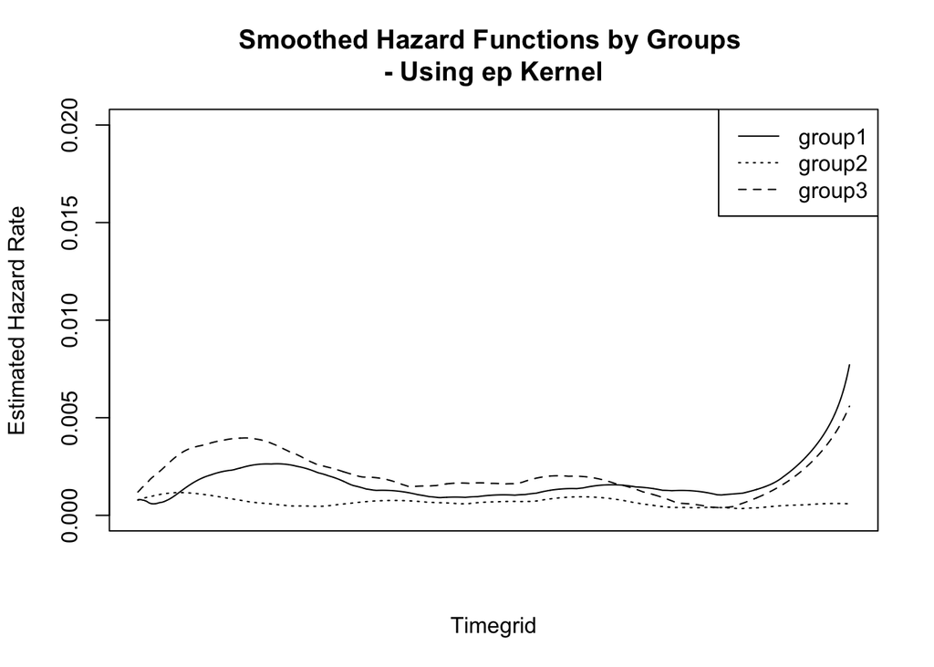

```r
est_haz_plot <- function(data=data, b=b, timegrid=timegrid, group='', max_haz = max_haz, kernel = kernel){

  if(group==''){
    out <- est_haz(data=data,b=b,timegrid=timegrid,group=group,kernel=kernel)
    plot(out, type="l", ylim=c(0,max_haz), lty=1,xlab="Timegrid", ylab="Estimated Hazard Rate", xaxt='n')
  }

  if(group!=''){
    out <- est_haz(data=data,b=b,timegrid=timegrid,group=group,kernel=kernel)
    gr <- unique(data[, group])
    plot(out[out$group==gr[1],"est_haz"], type="l",lty=1, ylim=c(0,max_haz), xlab="Timegrid", ylab="Estimated Hazard Rate",  xaxt='n', main = paste("Smoothed Hazard Functions by Groups \n- Using",kernel,'Kernel'))
    for(i in 2:length(gr)){
      lines(out[out$group==gr[i],"est_haz"], type="l",lty=(5-i))
    }
  }

  legend( x="topright",
          legend=c("group1","group2","group3"), lwd=1, lty=c(1,3,2))

}


# Example: use Epachnikov kernel
max_haz  <- 0.02
b        <- 100
timegrid <- seq(1,690,1)
kernel   <- 'ep'  #'unif', 'biw'
est_haz_plot(data=bone,b=b,timegrid=timegrid,group='g',max_haz=max_haz, kernel=kernel)
```

### Plots of estimated smoothed hazard function by kernels

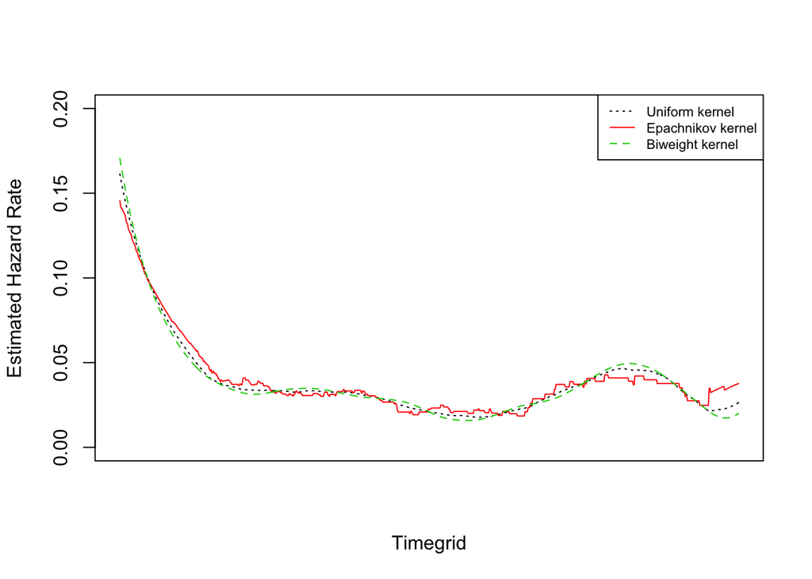

```r
est_haz_plot_by_kernel <- function(data=data, b=b, timegrid=timegrid, max_haz = max_haz){

  ep <- est_haz(data=data, b=b, timegrid=timegrid, group='', kernel='ep')
  unif <- est_haz(data=data, b=b, timegrid=timegrid, group='', kernel='unif')
  biw <- est_haz(data=data, b=b, timegrid=timegrid, group='', kernel='biw')

  plot(x=ep$timegrid, y=ep$haz, type="l", ylim=c(0, max_haz), lty=3, ylab="Estimated Hazard Rate", xlab="Timegrid",  xaxt='n')
  lines(x=ep$timegrid, y=unif$haz, lty=1,col=2)
  lines(x=ep$timegrid, y=biw$haz, lty=2,col=3)
  legend( x="topright",
          legend=c("Uniform kernel","Epachnikov kernel","Biweight kernel"), lwd=1, lty=c(3,1,2),cex=0.7,col=c(1,2,3))

  out <- data.frame(timegrid, ep$haz, unif$haz, biw$haz)
  return(out)

}

max_haz <- 0.2
b=1
timegrid <- seq(0,8,0.01)
test <- est_haz_plot_by_kernel(data=kid, b=b, timegrid=timegrid, max_haz=max_haz)
```

### Estimated smoothed hazard function using different Bandwidth Kernels

Plot the estimated smoothed hazard using different values of the parameter b in Bandwidth Kernels.

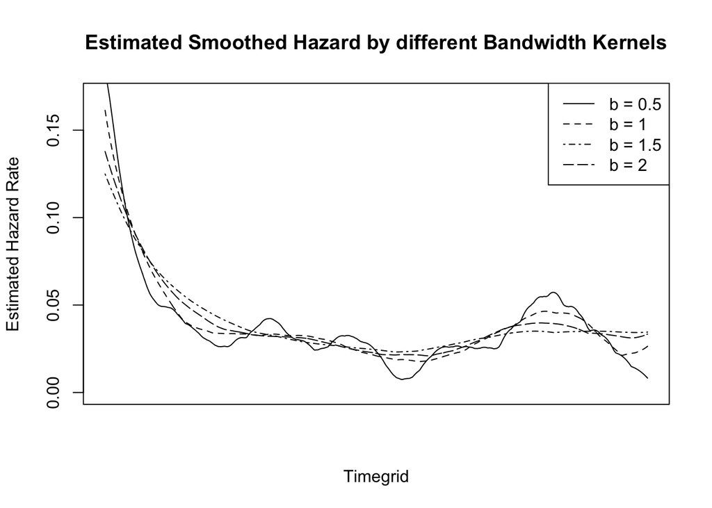

```r
est_haz_plot_by_bandwidth <- function(data=data, b=b, timegrid=timegrid, max_haz = max_haz, kernel='ep'){

  ep_b_0.5 <- est_haz(data=data, b=b[1], timegrid=timegrid, group='', kernel=kernel)
  ep_b_1   <- est_haz(data=data, b=b[2],   timegrid=timegrid, group='', kernel=kernel)
  ep_b_1.5 <- est_haz(data=data, b=b[3], timegrid=timegrid, group='', kernel=kernel)
  ep_b_2   <- est_haz(data=data, b=b[4],   timegrid=timegrid, group='', kernel=kernel)

  plot( x=timegrid, y=ep_b_0.5$haz, type="l", ylim=c(0, max_haz), lty=1, ylab="Estimated Hazard Rate",
        xlab="Timegrid", xaxt='n', main="Estimated Smoothed Hazard by different Bandwidth Kernels")
  lines(x=timegrid, y=ep_b_1$haz, lty=2)
  lines(x=timegrid, y=ep_b_1.5$haz, lty=5)
  lines(x=timegrid, y=ep_b_2$haz, lty=4)

  legend( x="topright",  legend=paste('b =',b), lwd=1, lty=c(1,2,4,5) )


  out <- data.frame(timegrid, ep_b_0.5$haz, ep_b_1$haz, ep_b_1.5$haz, ep_b_2$haz)

  return(out)
}

b        <- seq(0.5,2,0.5)
max_haz  <- 0.17
timegrid <- seq(0,8,0.01)

kid <- read.csv("kidney.csv")
kid$time <- kid$time/365
kid$status <- kid$death
data <- kid

test <- est_haz_plot_by_bandwidth(data=kid, b=b, timegrid=timegrid, max_haz=max_haz, kernel='ep')
```

### Variance of the estimated smoothed hazard function

```r
var_haz <- function(data, b, timegrid, group='', kernel='biw'){
  if(group==''){
    fit <- survfit(Surv(time, status) ~ 1,data=data, ctype=1)
    t_i <- summary(fit)$time
    cumhaz <- summary(fit)$cumhaz
    delta_cumhaz <- c(cumhaz[1], diff(cumhaz))
    varcumhar <- (summary(fit)$std.chaz)^2
    delta_varcumhar <- c(varcumhar[1], diff(varcumhar))
    td <- max(t_i)

    kernels<-matrix(NA,nrow=length(timegrid),ncol=length(t_i))

    if(kernel=="ep"){
      for (i in 1:length(timegrid)){
        for (j in 1:length(t_i)){
          kernels[i,j] <- ((k.ep(t=timegrid[i],ti=t_i[j],td,b))^2)*(delta_varcumhar[j])
          #print((k.ep(t=timegrid[i],ti=t_i[j],td,b)))
        }
      }
    }

    if(kernel=="unif"){
      for (i in 1:length(timegrid)){
        for (j in 1:length(t_i)){
          kernels[i,j] <- ((k.unif(t=timegrid[i],ti=t_i[j],td,b))^2)*(delta_varcumhar[j])
        }
      }
    }

    if(kernel=="biw"){
      for (i in 1:length(timegrid)){
        for (j in 1:length(t_i)){
          kernels[i,j] <- ((k.biw(t=timegrid[i],ti=t_i[j],td,b))^2)*(delta_varcumhar[j])
        }
      }
    }

    varhaz <- (rowSums(kernels, na.rm = T))/(b^2)
    varhaz <- data.frame(timegrid, varhaz)
    return(varhaz)
  }


  if(group!=''){

    fit <- survfit(Surv(time, status) ~ data[,group], data=data, ctype=1)
    g <- vector("list", length = length(summary(fit)$n))
    t_i <- vector("list", length = length(summary(fit)$n))
    cumhaz <- vector("list", length = length(summary(fit)$n))
    delta_cumhaz <- vector("list", length = length(summary(fit)$n))
    varcumhar <- vector("list", length = length(summary(fit)$n))
    delta_varcumhar <- vector("list", length = length(summary(fit)$n))

    breaks <- c(which(diff(summary(fit)$time)<0), length(summary(fit)$time))
    t_i[[1]] <- summary(fit)$time[1:breaks[1]]
    g[[1]] <- rep(unique(data[, group])[1], length(t_i[[1]]))
    cumhaz[[1]] <- summary(fit)$cumhaz[1:breaks[1]]
    delta_cumhaz[[1]] <- c(cumhaz[[1]][1], diff(cumhaz[[1]]))
    varcumhar[[1]] <- (summary(fit)$std.chaz[1:breaks[1]])^2
    delta_varcumhar[[1]] <- c(varcumhar[[1]][1], diff(varcumhar[[1]]))

    for(l in 2:length(breaks)){
      t_i[[l]] <- summary(fit)$time[(breaks[l-1]+1):breaks[l]]
      g[[l]] <- rep(unique(data[, group])[l], length(t_i[[l]]))
      cumhaz[[l]] <- summary(fit)$cumhaz[(breaks[l-1]+1):breaks[l]]
      delta_cumhaz[[l]] <- c(cumhaz[[l]][1], diff(cumhaz[[l]]))
      varcumhar[[l]] <- (summary(fit)$std.chaz[(breaks[l-1]+1):breaks[l]])^2
      delta_varcumhar[[l]] <- c(varcumhar[[l]][1], diff(varcumhar[[l]]))
    }

    x = kernels = td <- c()
    for(l in 1:length(summary(fit)$n)){
      kernels[[l]] <-matrix(NA,nrow=length(timegrid), ncol = length(t_i[[l]]))
      td[[l]] <- max(t_i[[l]])
    }


    if(kernel=="ep"){
      for(l in 1:length(summary(fit)$n)){
        for (i in 1:length(timegrid)){
          for (j in 1:length(t_i[[l]])){
            #if(l==1 & i %in% c(50, 150, 600)) {print(c("l=", l, "i=", i, "j=", j));print(((k.ep(t=timegrid[i],ti=t_i[[l]][j],td[[l]],b))^2)); print((delta_varcumhar[[l]][j]))}
            kernels[[l]][i,j] <- ((k.ep(t=timegrid[i],ti=t_i[[l]][j],td[[l]],b))^2)*(delta_varcumhar[[l]][j])
            #if(l==1 & i %in% c(50, 150, 600)) { print(kernels[[l]][i,j])}
          }
        }
      }
    }

    if(kernel=="unif"){
      for(l in 1:length(summary(fit)$n)){
        for (i in 1:length(timegrid)){
          for (j in 1:length(t_i[[l]])){
            kernels[[l]][i,j] <- ((k.unif(t=timegrid[i],ti=t_i[[l]][j],td[[l]],b))^2)*(delta_varcumhar[[l]][j])
          }
        }
      }
    }

    if(kernel=="biw"){
      for(l in 1:length(summary(fit)$n)){
        for (i in 1:length(timegrid)){
          for (j in 1:length(t_i[[l]])){
            kernels[[l]][i,j] <- ((k.biw(t=timegrid[i],ti=t_i[[l]][j],td[[l]],b))^2)*(delta_varcumhar[[l]][j])
          }
        }
      }
    }

    varhaz_tmp <- c()
    varhaz_tmp <- lapply(kernels, function(x) (rowSums(x, na.rm = T))/(b^2))
    gr <- rep(unique(data[, group]), each=length((varhaz_tmp[[1]])))
    varhaz <- c()
    varhaz <- data.frame(rep(timegrid,length(unique(data[, group]))), unlist(varhaz_tmp), gr)
    colnames(varhaz) <- c("timegrid", "var_haz", "group")
    return(varhaz)
  }
}
```

### Optimal function - g(b)

```r
####g(b) function
opti_gb <- function(b,u,data,kernel){

  fit_optim <- survfit(Surv(time, status) ~ 1, data=data, ctype=1)
  t_i_optim <- summary(fit_optim)$time
  cumhaz_optim <- summary(fit_optim)$cumhaz
  diffcumhz_optim <-c(cumhaz_optim[1], diff(cumhaz_optim) )

  ### gb1
  gb1<- vector()
  for (i in 1: ( length(u)-1) ) {

    est_hi <- est_haz(data=data, b=b, timegrid=u[i],group='',kernel= kernel)
    est_hi1 <- est_haz(data=data, b=b, timegrid=u[i+1],group='',kernel=kernel)
    gb1[i] <- ( u[i+1]-u[i] ) /2 *  (  ( est_hi$haz )^2 +  ( est_hi1$haz )^2   )
  }

  ### gb2
  gb2 <- matrix(NA,nrow= length(t_i_optim),ncol = length(t_i_optim))

  if(kernel=="unif"){

    for (i in 1:length(t_i_optim) ){
      for (j in 1:length(t_i_optim) ){
        gb2[i,j]<- - (2/b) * k.unif(t=t_i_optim[i],ti=t_i_optim[j],td=max(t_i_optim),b=b) * diffcumhz_optim[i]* diffcumhz_optim[j]
      }
    }
  }

  if(kernel=="ep") {

    for (i in 1:length(t_i_optim) ){
      for (j in 1:length(t_i_optim) ){
        gb2[i,j]<- - (2/b) * k.ep(t=t_i_optim[i],ti=t_i_optim[j],td=max(t_i_optim),b=b) * diffcumhz_optim[i]* diffcumhz_optim[j]
      }
    }
  }


  if(kernel=="biw") {

    for (i in 1:length(t_i_optim) ){
      for (j in 1:length(t_i_optim) ){
        gb2[i,j]<- - (2/b) * k.biw(t=t_i_optim[i],ti=t_i_optim[j],td=max(t_i_optim),b=b) * diffcumhz_optim[i]* diffcumhz_optim[j]
      }
    }
  }


  diag(gb2) <-0 # dont add i= j case so make diag(gb2 matrix )
  gb <- sum(gb1) + sum(gb2)

  return(gb)

}
```

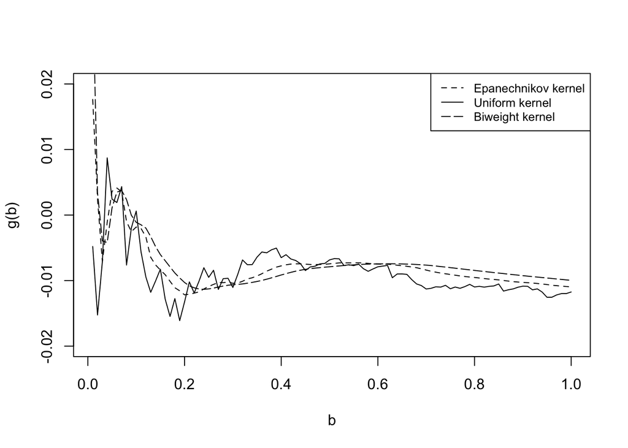

```r
optimal_b_plot <- function (u, bgrid,data ){

  pts_ep<-vector()
  pts_unif<-vector()
  pts_biw<-vector()

  for (p in 1:length(bgrid)) {
    pts_ep[p]<-opti_gb(b=bgrid[p],u=u,data=data, kernel='ep')
    pts_unif[p]<-opti_gb(b=bgrid[p],u=u,data=data, kernel='unif')
    pts_biw[p]<-opti_gb(b=bgrid[p],u=u,data=data, kernel='biw')
  }

  ### fig6.5
  plot(bgrid,pts_ep,type = 'l',lty=2,xlab = "b", ylab = "g(b)", ylim=c(-0.02, 0.02))
  lines(bgrid,pts_unif,lty=1 )
  lines(bgrid, pts_biw,lty=5)
  legend("topright", legend=c("Epanechnikov kernel", "Uniform kernel","Biweight kernel"),lty=c(2,1,5), cex=0.8)
  ### optim bgrid
  ep_optim <- bgrid[(pts_ep==min(pts_ep))]
  unif_optim <-bgrid[(pts_unif==min(pts_unif))]
  biw_optim <- bgrid[(pts_biw==min(pts_biw))]

  out <- data.frame(ep_optim,unif_optim,biw_optim)

  return(out)

}


kid <- read.csv("kidney.csv")
kid$status <- kid$death
kid <- kid[order(kid$time), ]
kid$time <- kid$time/365

u     <-  seq(0,6,1)
bgrid <- seq(0.01,1,0.01)
test  <- optimal_b_plot(u=u, bgrid=bgrid, data=kid)
```

```r
kable(test)%>%
  kable_styling(bootstrap_options = "striped", full_width = F)
```

| ep_optim | unif_optim | biw_optim |
| --- | --- | --- |
| 0.2 | 0.19 | 0.24 |

### Reference

Klein, J.P. and Moeschberger, M.L., Survival Analysis: Techniques for Censored and Truncated Data, Pg165-198, Springer, Berlin, 2nd edition, 2003.